# 1D Random Walk Simulation

Jacob J. Sauerhoefer

## Introduction

Random walks are random processes with applications in engineering and science, including modeling the path of molecules, animal foraging behavior and stock price analysis. By analyzing simulations of these random walks the validity of limit laws and the central limit theorem can be established and insight can be gained into their function and behavior.

## Random Walk

Given a random variable with outcomes of +1 or -1 with equal probability:

$X_i=\begin{cases} 1 \text{ with probability } \frac{1}{2} \\ -1 \text{ with probability } \frac{1}{2} \end{cases}$

The expectation of this random variable is:

$\mathbb{E}X_i = \mu = \sum x_ip_i = 1(1/2) + -1(1/2) = 0$

And its variance:

$\text{Var}X_i = \sigma^2 =\mathbb{E}X^2 - (\mathbb{E}X)^2 = \sum x_i^2p_i - 0 \\= (1)^2(1/2)+(-1)^2(1/2) - 0= (1/2)+(1/2) -0 = 1$

These are the theoretical values that we expect our simulations outcomes to approach.

## Partial Sum Process

Given a sequence of the above random variable that are i.i.d., a partial sum process can be defined as:

$S_{n}=\sum_{i=1}^{n}X_i$

This process is a simple random walk and can be implemented using a cumulative sum function, that generates a sequence of these partial sums. Here, a simulation of a partial sum with 1000 steps is run.

```r
library(ggplot2)
library(gganimate)
library(randomcoloR)
library(dplyr)
```

[figure not shown]

```r
set.seed(2)

n <- 1000 #number of steps
probs <- rep(0.5, n) #list of probabilities

prod <- cumprod(sample(c(-1, 1), n, TRUE))
proddat <- data.frame(x = seq_along(prod), y = prod)
p <- ggplot(proddat,aes(x = x, y = y)) + geom_line()


Sn <- cumsum(prod)
Sn_value <- tail(Sn, 1)
df <- data.frame(run = 1, x = seq_along(Sn), y = Sn, color=randomColor())
a <- ggplot(df,aes(x = x, y = y)) + geom_line(alpha=0.7)
anim_a <- a + transition_reveal(seq_along(x))
anim_a
```

## Strong Law of Large Numbers

The Strong Law of Large Numbers (SLLN) states that an observed probability average will approach a theoretical probability expectation as the number of trials approaches infinity.

$\frac{S_n}{n}\xrightarrow{n\rightarrow\infty}\mu$

By the SLLN, from the single run simulation we find $\mu$ being approximate to the theoretical expectation of 0:

```r
mean <- Sn_value/n
mean
```

```
## [1] 0.05
```

## Central Limit Theorem (CLT)

### Verification Using Multiple Simulations

Because simulations cannot be run indefinitely, in order to establish a validity of the central limit theorem, multiple simulations must be run. By running the random walk simulation multiple times, the final values of each run can be used to establish an approximate normal distribution.

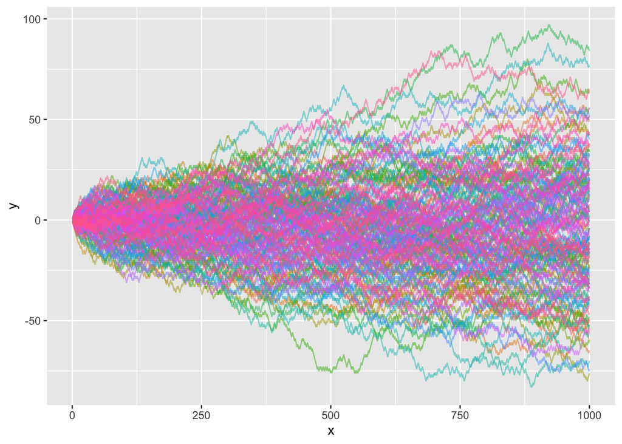

```r
runs <- 150 #number of runs

func_random_walk <- function() {
  for (i in 2:runs) {
    i
    products <- cumprod(sample(c(-1, 1), n, TRUE))
    out <- cumsum(products)
    x <- seq_along(out)
    y <- out
    tmp <- data.frame(run = i, x = x, y = out, color=randomColor())
    df <- rbind(df, tmp)
  }
  return(df)
}
df2 <- func_random_walk()
a <- ggplot(df2,aes(x = x, y = y)) + geom_line(aes(color=color), alpha=0.5) + theme(legend.position = "none")
a
```

The central limit theorem states that given a random sample from any type of probability distribution, if the size of the sample n is sufficiently large then the sample mean $\bar{X}$ follows an approximate normal distribution.

$\mathbb{P}(a\leqslant\frac{S_n-n\mu}{\sigma \sqrt{n}}\leqslant b)\xrightarrow{n\rightarrow\infty}\mathbb{P}(a\leqslant Z \leqslant b)$

The normal approximation to $S_n$

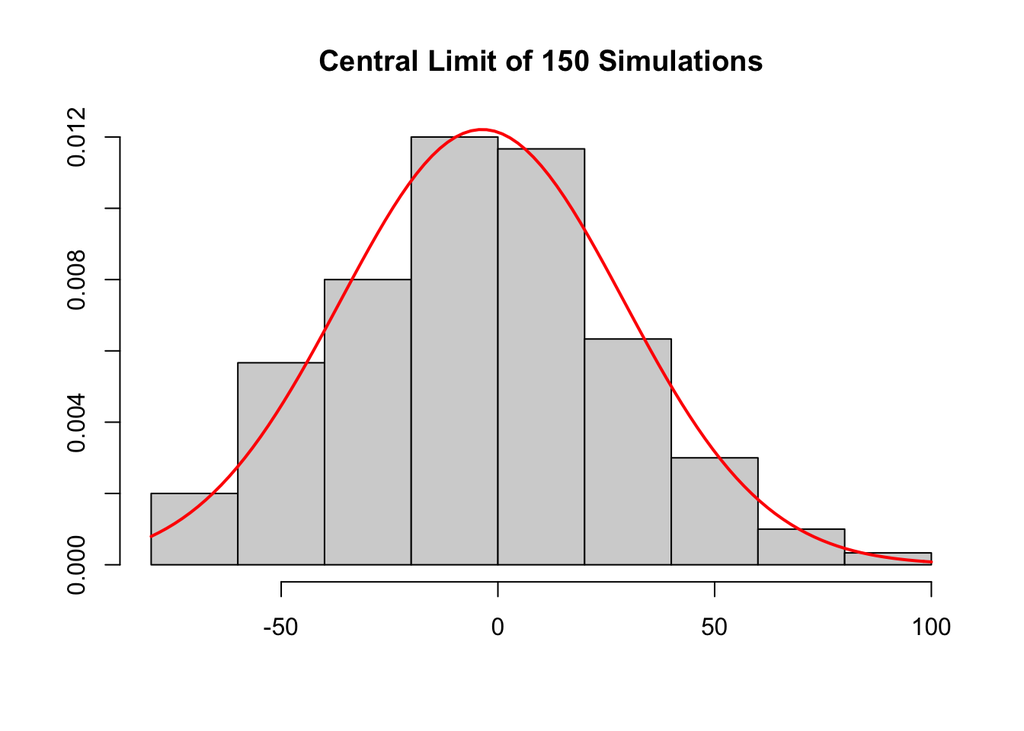

```r
final_values <- df2 %>% group_by(run) %>% summarise(y = last(y))

v <- var(final_values$y)
s <- sd(final_values$y)
m <- mean(final_values$y)
hist(final_values$y, prob=TRUE,ylab=NULL,main="Central Limit of 150 Simulations",xlab=NULL)
curve(dnorm(x,mean=m,sd=s),add=TRUE,lwd=2,col="red")
```